# Modelado de tópicos Vol. 2. Structural Topic Modeling

Temas en revistas con targets diferentes

```r
library(tidyverse)
```

```r
library(stm)
```

```r
library(topicmodels)
library(tidytext)
library(tictoc)
```

## Introducción

En general, una tarea que es muy frecuente en el análisis de textos es intentar dividir nuestro corpus en cierta cantidad de grupos para poder entenderlos por separado. Algo así como hacer una primera lectura de nuestro corpus sin tener que leer los documentos uno por uno. Las técnicas de modelado de tópicos son una gran aliada para este tipo de taras.

En este notebook vamos a introducir una técnica para efecutar esta tarea que se diferencia de Latent Dirichlet Allocation (LDA) en varios aspectos.

## Structural Topic Modeling (STM). Analizando revistas para mujeres y para hombres

STM provee un marco general para el modelado de tópicos pero su característica fundamental es que permite incorporar información de covariables a nivel de documento.

Este punto es sumamente importante porque permite flexibilizar uno de los supuestos más fuertes de LDA: que los tópicos son constantes para todo el corpus. STM permite incorporar la influencia de ciertas covariables sobre los tópicos en dos aspectos:

- la prevalencia de los tópicos (el peso de cada tópico en cada documento)
- el contenido de los tópicos (la probabilidad de cada palabra de aparecer en el corpus)

Estas covariables pueden mejorar la inferencia y la interpretabilidad de los temas detectados.

En estos links pueden encontrar algunos papers que detallan algunos de los supuestos y métodos de estimación de STM

- [The Structural Topic Model and Applied Social Science](https://scholar.princeton.edu/files/bstewart/files/stmnips2013.pdf)
- [A Model of Text for Experimentation in the Social Sciences](https://scholar.princeton.edu/sites/default/files/bstewart/files/a_model_of_text_for_experimentation_in_the_social_sciences.pdf)

Y aquí [el sitio del paquete implmenetado en R](https://www.structuraltopicmodel.com/).

Si bien no nos vamos a meter en detalle en la matemática del modelo diremos que en STM se reemplazan las distribuciones de probabilidad que se usan en LDA por modelos lineales generalizados para poder correlacionar las covariables con la distribución de tópicos por documentos y de palabras por tópico.

Veamos un ejemplo con el mismo corpus que utilizamos la semana pasada:

```r
revistas <- read_csv('../data/revistas_limpias_final.csv')
head(revistas)
```

| id | categoria | fecha | titulo | text |
| --- | --- | --- | --- | --- |
| 1 | Hombre | 4 de marzo de 2018 | Los ex caddies que se organizaron para poder seguir jugando | Ninguno tenía la plata necesaria ni el apellido indicado para entrar en una cancha de golf. Eran chicos de 8 a 12 años que se escabullían en ese territorio prohibido a cambio de cargar palos bajo el s… |
| 2 | Hombre | 2 de marzo de 2018 | El documental sobre la gran estafa del doping en los Juegos Olímpicos | Del bidón que habría drogado a Branco en Italia 90 a la manipulación en 2007 de resultados de la NBA por parte del árbitro Tim Donaghy, los escándalos de este tipo en el mundo deportivo son moneda cor… |
| 3 | Hombre | 15 de febrero de 2018 | Porfolio fotográfico: Guillermo Miconi | Las ciudades contemporáneas están repletas, atestadas de gente. Mi juego es vaciarlas. Lograr el retrato de una megalópolis desierta. Utilizo, entonces, las posibilidades que me da la cámara fotográfi… |
| 4 | Hombre | 3 de diciembre de 2017 | Pipi Piazzolla, el músico que toca en la banda millonaria | \r\n\r\nEn el 84 empecé a ir a la cancha y ahí fue la primera vez que vi una murga en mi vida. No era como ahora, que hay murgas en todas las plazas. Fue un primer acercamiento, empezar a golpear el c… |
| 5 | Hombre | 29 de marzo de 2016 | Perfil Geek: hoy Ezequiel Calcarami | \r\nComprar un auto cero kilómetro es una experiencia, además de costosa, emocionalmente movilizante para el comprador aunque no muchas veces satisfactoria. Para redondear una compra hay que visitar d… |
| 6 | Hombre | 28 de marzo de 2016 | 3 shows imperdibles en Buenos Aires | \r\n\r\n\r\nGoran Bregovic, músico y compositor nacido en Sarajevo (antigua Yugoslavia) quién ya estuvo algunas veces en Argentina, regresa con un concierto en el que presenta su último álbum titulado… |

Vamos a normalizar, primero, los campos de texto. Con esta instrucción cambiamos el encoding de texto de los campos `text` y `title` y lo pasamos a ASCII. Esta es una forma bastante rápida de eliminar tildes, ñ y otros acentos.

```r
revistas <- revistas %>%
                mutate(text = stringi::stri_trans_general(text, "Latin-ASCII"),
                       titulo = stringi::stri_trans_general(titulo, "Latin-ASCII"))
```

Eliminamos los dígitos que encontremos en el texto…

```r
revistas <- revistas %>%
          mutate(text = str_replace_all(text, '[[:digit:]]+', ''))
```

Ahora podemos tokenizarlo:

```r
revistas_tidy <- revistas %>%
                unnest_tokens(word, text)
```

```r
stop_words <- read_delim('../data/stopwords.txt',
                         delim = '\t',
                         col_names = c('word')) %>%
                        mutate(word=stringi::stri_trans_general(word, "Latin-ASCII"))
## Aquí agregamos algunas palabras al listado de stopwords...
stop_words <- stop_words %>%
                bind_rows( tibble(word=c('ano', 'anos', 'ohlala', 'foto', 'the')))
```

```r
revistas_tidy <- revistas_tidy %>%
                anti_join(stop_words)
metadata <- revistas_tidy %>%
                  select(id, categoria) %>%
                  distinct() %>%
                  left_join(revistas %>% select(id, text))
```

Primero, generamos nuestra tabla tidy de conteos

```r
word_counts <- revistas_tidy %>%
        group_by(id, word) %>%
        summarise(n=n()) %>%
        ungroup()
```

### Modelado de tópicos: STM

Para hacer el modelado de temas como se implementa aquí, necesitamos generar una `DocumentFrequencyMatrix`, un tipo especial de matriz del paquete `quanteda` (por supuesto, esto es solo una implementación específica del concepto general de una TFM).

```r
revistas_dfm <- word_counts %>%
                cast_dfm(id, word, n)

revistas_dfm
```

```
Document-feature matrix of: 3,930 documents, 111,484 features (99.8% sparse).
    features
docs aag abajo abandonarlo abierto abiertos abre abrian aca
   1   2     2           1       1        1    1      1   5
   2   0     0           0       0        0    0      0   0
   3   0     0           0       0        0    0      0   0
   4   0     0           0       0        0    0      0   0
   5   0     0           0       0        0    0      0   0
   6   0     0           0       0        0    0      0   0
    features
docs aceptaran acumulacion
   1         1           1
   2         0           0
   3         0           0
   4         0           0
   5         0           0
   6         0           0
[ reached max_ndoc ... 3,924 more documents, reached max_nfeat ... 111,474 more features ]
```

```r
tic()

stm_15 <- stm(documents = revistas_dfm,
     K = 15,
     content = ~ categoria,
     max.em.its = 75,
     data = metadata,
     init.type = "Spectral")
```

```
Beginning Spectral Initialization
     Calculating the gram matrix...
     Using only 10000 most frequent terms during initialization...
```

Generamos las dos matrices fundamentales: la de palabras x tópico y la documentos x tópico

```r
betas_stm <- tidy(stm_15, matrix='beta')
```

```
`tbl_df()` was deprecated in dplyr 1.0.0.
Please use `tibble::as_tibble()` instead.
```

```r
doc_2_topics_stm <- tidy(stm_15, matrix='theta')
```

Primero, veamos las matrices de palabras por topicos.

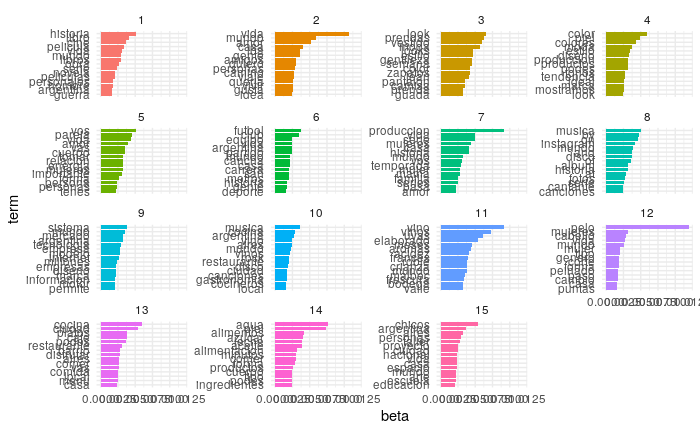

```r
 betas_stm %>%
  group_by(topic) %>%
  slice_max(beta, n = 15) %>%
  ungroup() %>%
  arrange(topic, -beta) %>%
  mutate(term = reorder_within(term, beta, topic)) %>%
  ggplot(aes(beta, term, fill = factor(topic))) +
  geom_col(show.legend = FALSE) +
  facet_wrap(~ topic, scales='free_y') +
  scale_y_reordered() +
  theme_minimal()
```

En el caso de STM podemos ver los siguientes tópicos:

1. Entretenimientos/espectáculos
2. Misc.
3. Moda, look
4. Moda, diseño
5. Pareja
6. Deportes
7. Espectáculos/series
8. Música y discos
9. Autos (tecnología? economía?)
10. Música y cocina (salidas, quizás…)
11. Vinos
12. Cuidado del pelo
13. Cocina y restaurantes
14. Alimentación, cuidado del cuerpo
15. Niños y educación

### Algunas herramientas de validación de STM

Ahora bien, una vez que hemos estimado nuestro modelo de tópicos STM es sumamente importante proceder a la validación del mismo. Vamos a ver que el paquete `stm` tiene implementadas algunas funciones que hacen bastante fácil esta tarea de validación.

Vamos a ver dos posibles formas de avanzar en una validación del modelo. La primera, es analizar las palabras que forman parte de cada tópico. Es decir, lo que hemos venido haciendo. Pero con una diferencia: hasta aquí habíamos trabajado con las palabras que tienen mayor $\beta$ es decir, mayor probabilidad de pertenecer a cada tópico. STM nos permite obtener otros listados de palabras. Llamemos a la siguiente función:

```r
labelTopics(stm_15)
```

```
Topic 1 Top Words:
     Highest Prob: historia, libro, cine, pelicula, vida, mundo, libros
     FREX: puccio, herzog, aira, patan, saxer, vallee, fitzcarraldo
     Lift: aamec, abalanzarse, abarcarlo, abbiamo, abducido, abejascaja, abnegado
     Score: patan, puccio, aira, herzog, ragendorfer, puel, mapuches
Topic 2 Top Words:
     Highest Prob: vida, mundo, amor, casa, iba, gente, amigos
     FREX: cari, aprendi, pude, pense, llorar, camilo, aventuras
     Lift: abandonemos, abatido, abayuba, abduccion, abdujo, abonan.coco, abordan.ficciones
     Score: cari, abayuba, atrevi, planetarios, iba, pichu, aventuras
Topic 3 Top Words:
     Highest Prob: look, prendas, vestido, moda, looks, estilo, gentileza
     FREX: blusa, mileinstagram, ohlaleando, besossofi, malter, trademark, chatitas
     Lift: _asi, _blanco, _cruzo, _en, _jeanettemadsen_, _jeanettemadsen_yuwei, _ni
     Score: guada, looks, malter, falda, sandalias, prendas, blusa
Topic 4 Top Words:
     Highest Prob: color, piel, colores, moda, estilo, diseno, produccion
     FREX: eau, lip, fragancia, pestanas, rovedaque, labios, fragancias
     Lift: abotinado, addict, afrutada, annoni, antifatiga, apilable, asos
     Score: beauty, rovedaque, cejas, fragancia, hidratante, labial, fps
Topic 5 Top Words:
     Highest Prob: vos, pareja, vida, amor, vas, cuerpo, tomar
     FREX: mescon, planetas, parto, menstruacion, partos, lactancia, ejercicios
     Lift: aaarbaentrenamiento, abalanzamos, abandonaremos, abandonarte, abarque, abdomenes, abierta.tu
     Score: mescon, parto, planetas, obstetra, aliadocon, lactancia, pluton
Topic 6 Top Words:
     Highest Prob: futbol, club, equipo, vida, argentina, partido, mundo
     FREX: afa, baigorri, fifa, nadal, arquero, gorbea, corbatta
     Lift: arquero, gorbea, nadal, a.n.i.m.a.l, aafg, abdicacion, abdo
     Score: baigorri, afa, corbatta, tunante, fifa, gabelli, river
Topic 7 Top Words:
     Highest Prob: produccion, vida, serie, mujeres, casa, historia, mundo
     FREX: tanoira, guajardo, yamila, ines, engel, porno, lectoure
     Lift: abstenia, abstract, acm, akinnagbe, alcoholera, amchitka, anorexica
     Score: tanoira, guajardo, yamila, tale, handmaid's, engel, lectoure
Topic 8 Top Words:
     Highest Prob: musica, by, on, instagram, mundo, and, disco
     FREX: shared, oct, celestebarber, pdt, friends, at, photo
     Lift: acerbi, alexisren, allthatisthreeuna, always, anastasia, anyone, arozona
     Score: shared, at, celestebarber, oct, cannabis, album, pm
```

[output cut: 20 more lines]

```
Topic 13 Top Words:
     Highest Prob: cocina, ciudad, platos, cafe, podes, restaurante, barrio
     FREX: menu, sandwiches, bircz, pasteleria, brunch, postre, platos
     Lift: abbesses, abisko, aboitiz, aceros, acertijos, ache, aeroclub
     Score: menu, restaurante, langostinos, chef, sandwiches, sabores, salsa
Topic 14 Top Words:
     Highest Prob: agua, piel, alimentos, azucar, leche, aceite, alimentacion
     FREX: cucharadita, bol, grasas, cucharadas, sebo, nutrientes, grasa
     Lift: acesulfame, agave, agregales, alcalino, alergicos, amapola, antiinflamatorias
     Score: grasas, calorias, grasa, ml, azucar, aceite, harina
Topic 15 Top Words:
     Highest Prob: chicos, argentina, aires, personas, taller, proyecto, ciudad
     FREX: taller, docentes, escuelas, especies, fundacion, educativo, aves
     Lift: a.a.e.e.h, abandonos, abdul, abete, abis, abogada.el, abogadas
     Score: sillerico, innocence, aves, nisman, nievas, educativo, especies
```

Esta salida nos muestra cuatro listados de palabras. Vamos a centrarnos en las dos primeras.

- Highest prob: son las palabras dentro de cada tema con la mayor probabilidad (deducidas directamente del parámetro de distribución tema-palabra $\beta$). Son las que usamos en los plots de más arriba.
- FREX: es una métrica que intenta combinar la frecuencia ($\beta$) con la exclusividad. Es decir, las palabras con alta FREX son palabras que distinguen temas: es decir, son frecuentes y exclusivas. Esto se calcula tomando la media armónica del rango por probabilidad dentro del tópico (frecuencia, es decir, el parámetro $\beta$) y la exclusividad es una medida que trata de cuantificar el uso relativo de un término en un tópico en relación al uso que se le da en otros tópicos.

Fijémonos el tópico 9:

Topic 9 Top Words: Highest Prob: sistema, mundo, mercado, argentina, tecnologia, empresa, modelo FREX: nm, torque, usb, llantas, suv, hardware, abs Lift: aa, aaa, aac, aade, aapresid, aaro, aasbo Score: pulgadas, torque, nm, llantas, suv, cv, gb

Si vemos las palabras de alto $\beta$ pareciera que habla de economía o algo así. Pero si vemos las de FREX aparecen temas vinculados a autos. Un paso siguiente para validar este tópico sería tratar de leer documentos con alta frecuencia de este tópico.

Para examinar documentos que están altamente asociados con temas, la función `findThoughts()` puede ser usada. Esta función imprimirá los documentos altamente asociados con cada tema. Leer estos documentos es útil para comprender el contenido de un tema e interpretar su definicion.

```r
findThoughts(stm_15,
             texts=metadata %>% mutate(text = str_sub(text, 1, 200)) %>% select(text) %>% pull(),
             n=10,
             topics=9)
```

```
 Topic 9:

En el mundo de los fabricantes de autos, el valor simbolico de la insignia es, a veces, el mayor capital del grupo empresario que la comercializa, y por eso son cuestionables las campanas de difusio
    En la primera mitad de , el gobierno nacional anuncio con bombos y platillos la baja de aranceles para la importacion de vehiculos electricos, hibridos y de propulsion a hidrogeno. La noticia genero e


Los  formaron parte de una decada inolvidable para los amantes de los fierros, especialmente por la aparicion de los hatchbacks picantes, versiones deportivas de coches populares, un concepto que

Fue a principios de los  cuando la industria japonesa se propuso conquistar los mercados del mundo. Entonces lanzo uno de sus principales representantes, concebido como un vehiculo economico y popul


La quinta generacion del Ford Mondeo se vendia en nuestro pais desde , pero el ultimo restyling del buque insignia de la marca de Detroit trae suficientes cambios como para anunciarse con todo. So

A finales del ano pasado, Ford anuncio la renovacion de su gama mas alta y la llegada durante  de las nuevas versiones del Mondeo, el C-Max y la Kuga. Desde su llegada al pais hace seis anos, la Kug

Los autos hibridos circulan por los caminos del mundo hace una decada. Y los electricos estan empezando a ganar terreno en los mercados centrales. Casi a diario escuchamos una nueva de Elon Musk, el



Desde su aparicion hace seis anos, la Volkswagen Amarok se gano un lugar merecido en el pais de las pick-ups. Con fama de ser la mas comoda, su andar de auto y sus prestaciones de confort marcar

Pocos autos sacudieron tanto el tablero. Cuando llego el Ford Ka, en , todos hablaban de el. Que era un auto para mujeres, decian los muchachos. Y las mujeres coincidian: era simpatico, facil de man

La octava edicion del Salon Internacional de Buenos Aires sacudio la agenda del sector y las marcas concentraron buena parte de sus lanzamientos del ano en esta muestra que, en pleno auge de venta d
```

Al ver los primeros 5 documentos parece claro que se trata de tópico que habla de autos, sobre todo.

#### Actividad

Repetir el ejercicio de validación con el tópico 5. ¿Qué pueden decir al respecto?

```r
labelTopics(stm_15, topic=5)
```

```
Topic 5 Top Words:
     Highest Prob: vos, pareja, vida, amor, vas, cuerpo, tomar
     FREX: mescon, planetas, parto, menstruacion, partos, lactancia, ejercicios
     Lift: aaarbaentrenamiento, abalanzamos, abandonaremos, abandonarte, abarque, abdomenes, abierta.tu
     Score: mescon, parto, planetas, obstetra, aliadocon, lactancia, pluton
```

```r
findThoughts(stm_15,
             texts=metadata %>% mutate(text = str_sub(text, 1, 200)) %>% select(text) %>% pull(),
             n=10,
             topics=5)
```

```
 Topic 5:
     Foto: OHLALA!
          Mucha energia sutil este mes envolviendo el planeta. Nos va a atravesar hasta lo mas ajeno, como si nos pasara a nosotras. Con el Sol en Acuario, con la Luna en Piscis y con
    Foto: OHLALA!
          Mucha energia sutil este mes envolviendo el planeta. Nos va a atravesar hasta lo mas ajeno, como si nos pasara a nosotras. Con el Sol en Acuario, con la Luna en Piscis y con
    Vamos a tener que aprender a mediar velocidades extremas. Por un lado, tres planetas en el signo Tauro nos van a llevar a buscar lo conveniente, lo seguro, lo tangible, lo que podemos saborear serenam
    Vamos a poder alcanzar logros  que venian postergados y a estar cargadas de confianza y optimismo, expresando a fondo nuestros talentos y lo mas genuino de nuestra individualidad. Solo vamos a tener q
    Foto: PixabayCon la Luna en Capricornio y con Saturno alejandose de Sagitario, pero aun ahi, con su presencia que se hace mas intensa por estar en los ultimos grados del signo; vamos a estar coordinan
    Tres planetas dentro de la franja zodiacal escorpiana van a movilizar al planeta entero, que va a estar haciendo acrobacia con la sombra. Lo mas oscuro de todo y de todos va a estallar para que nada q
    Foto: LatinstockLos radares ultrasonicos multidimensionales de la Luna en Acuario nos van a meter en la ola infinita del ahora y vamos a lograr integrar a esta realidad capricorniana una vibracion mas
    La paciencia no va a ser el punto fuerte de nadie este mes, con Marte, Urano y Venus en Aries. Vamos a ir directamente al grano de cada situacion, sin vacilaciones, y el aire va a estar cargado de chi
    Con la Luna en Escorpio, van a estar aflorando de tu intimidad esas emociones cuidadosamente controladas: las mas desagradables y las mas potentes. No dejes que tus miedos le ganen a este proceso en e
    Junio nos va a encontrar repartidas entre varios intereses, compartiendo experiencias, livianas de equipaje, curiosas y entusiastas.Y como no podia ser de otra manera y para dar constancia de la gener
```

### Comparando con un modelo LDA

Vamos a entrenar un LDA de 15 tópicos. La idea es tenerlo como “benchmark” para comparar los resultados con los que van a salir de STM.

Generamos la DTM:

```r
revistas_dtm <- word_counts %>%
                  cast_dtm(id, word, n)

revistas_dtm
```

```
<<DocumentTermMatrix (documents: 3930, terms: 111484)>>
Non-/sparse entries: 889157/437242963
Sparsity           : 100%
Maximal term length: NA
Weighting          : term frequency (tf)
```

Entrenamos el LDA (en realidad, lo tenemos pre-entrenado)

```r
#lda_15 <- LDA(revistas_dtm, k=15, control = list(seed = 9514))
lda_15 <- read_rds('../models/lda_15.rds')
```

Generamos las matrices de betas y gammas:

```r
betas_lda <- tidy(lda_15, matrix='beta')
doc_2_topics_lda <- tidy(lda_15, matrix='gamma')
```

Y veamos las palabras más relevantes en cada tópico de lDA

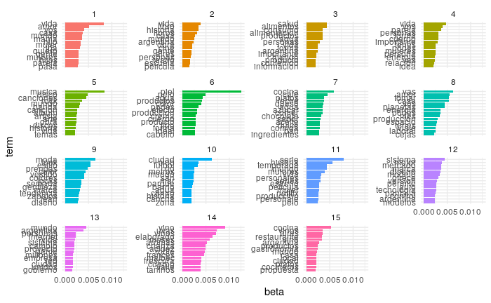

```r
 betas_lda %>%
  group_by(topic) %>%
  slice_max(beta, n = 15) %>%
  ungroup() %>%
  arrange(topic, -beta) %>%
  mutate(term = reorder_within(term, beta, topic)) %>%
  ggplot(aes(beta, term, fill = factor(topic))) +
  geom_col(show.legend = FALSE) +
  facet_wrap(~ topic, scales='free_y') +
  scale_y_reordered() +
  theme_minimal()
```

Podemos etiquetar de alguna forma estos tópicos

1. Misc.
2. Entretenimiento general (libros, películas, series, TV)
3. Alimentación y salud (con otras palabras raras)
4. Pareja y cuerpo
5. Músca
6. Cuidado del cuerpo
7. Cocina
8. Misc.
9. Moda (ropa, zapatos, etc.)
10. Deportes
11. Entretenimiento (TV, series)
12. Tecnología/autos (?)
13. Economía/tecnología
14. Vinos
15. Cocina y gastronomía

| Tópico nro. | STM | LDA |
| --- | --- | --- |
| 1 | Entretenimientos/espectáculos | Misc. |
| 2 | Misc. | Entretenimiento general (libros, películas, series, TV) |
| 3 | Moda, look | Alimentación y salud (con otras palabras raras) |
| 4 | Moda, diseño | Pareja y cuerpo |
| 5 | Horóscopo | Músca |
| 6 | Deportes | Cuidado del cuerpo |
| 7 | Espectáculos/series | Cocina |
| 8 | Música y discos | Misc. |
| 9 | Autos (tecnología? economía?) | Moda (ropa, zapatos, etc.) |
| 10 | Música y cocina (salidas, quizás…) | Deportes |
| 11 | Vinos | Entretenimiento (TV, series) |
| 12 | Cuidado del pelo | Tecnología/autos (?) |
| 13 | Cocina y restaurantes | Economía/tecnología |
| 14 | Alimentación, cuidado del cuerpo | Vinos |
| 15 | Niños y educación | Cocina y gastronomía |

Vemos cómo hay algunos tópicos que aparecen en ambos modelos: vinos, entretenimiento, cocina y gastronomía. No obstante, STM pareciera ser un poco más específico. Hay menos tópicos no interpretables y a su vez, pareciera haber menos mezclas en los tópicos.

Por ejemplo, en LDA vemos que el tópico 4 parece hablar de dos cosas diferentes: pareja y cuidado del cuerpo. En cambio, estos dos temas aparecen separados como dos tópicos diferenciados en STM.

A su vez, en LDA vemos que hay un tópico que habla de “entretenimiento en general”. En cambio, hay 3 tópicos al respecto en STM y con temas bien delimitados.

Por último, veamos cómo se distribuye la prevalencia de cada tópico según nuestra variable de corte:

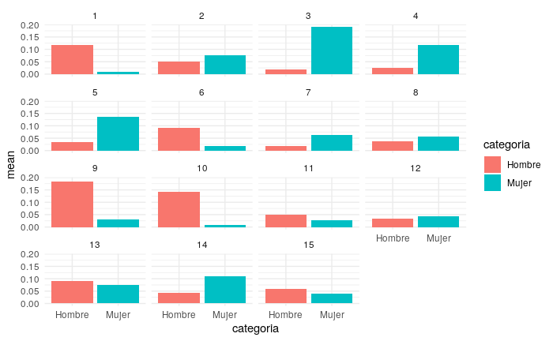

```r
doc_2_topics_stm <- doc_2_topics_stm %>%
  rename(id=document) %>%
  left_join(metadata)
doc_2_topics_stm %>%
  group_by(categoria, topic) %>%
  summarise(mean = mean(gamma)) %>%
  drop_na() %>%
  ggplot(aes(x=categoria, y=mean, fill=categoria)) +
    geom_col(position='dodge') +
    facet_wrap(~topic) +
    theme_minimal()
```

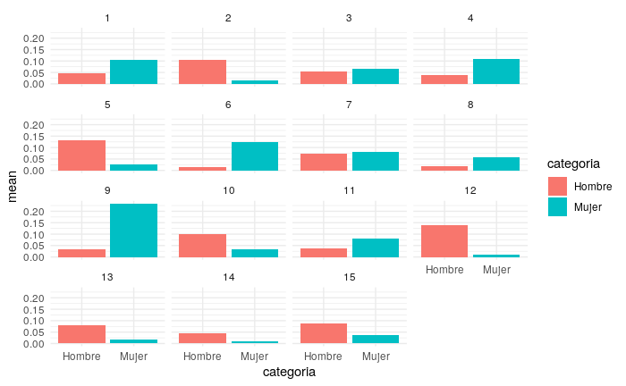

```r
doc_2_topics_lda <- doc_2_topics_lda %>%
  rename(id=document) %>%
  mutate(id=as.integer(id)) %>%
  left_join(metadata)
doc_2_topics_lda %>%
  group_by(categoria, topic) %>%
  summarise(mean = mean(gamma)) %>%
  drop_na() %>%
  ggplot(aes(x=categoria, y=mean, fill=categoria)) +
    geom_col(position='dodge') +
    facet_wrap(~topic) +
    theme_minimal()
```

Pareciera que se observan diferencias más marcadas en el modelo STM. Lo cual era esperable, en tanto era el objetivo de introducir covariables.

Estas diferencias aparecen aunque más atenuadas en el caso de LDA.